# Inference for Numerical Data

## IQ and Sex

```
##     IQ    sex
## 24 112   male
## 4  123   male
## 44 120 female
## 43 119 female
## 52 118 female
## 30 111   male
```

Consider a data set containing the IQs of 36 men and the IQs of 36 women, \(W \sim X\). Can use this data to test the following?

\[ H_0: \mu_{M} - \mu_{F} = 0 \\ H_A: \mu_{M} - \mu_{F} \ne 0 \]

```r
(ds <- d %>%
  group_by(sex) %>%
  summarize(mean = mean(IQ),
            s = sd(IQ),
            n = n()))
```

```
## Source: local data frame [2 x 4]
##
##      sex  mean     s     n
##   (fctr) (dbl) (dbl) (int)
## 1 female   118  6.57    36
## 2   male   115  3.92    36
```

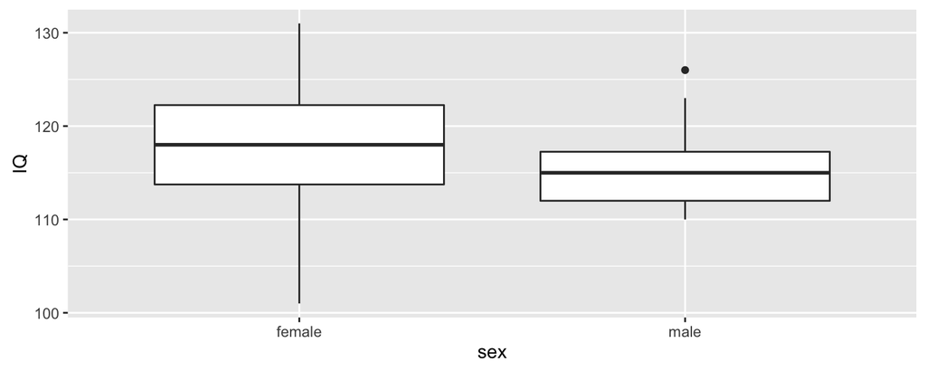

## Two sample t-test

- We have a point estimate

```r
diff(ds$mean)
```

```
## [1] -2.83
```

- We can calculate a standard error

```r
sqrt(ds$s[1]^2 / ds$n[1] + ds$s[2]^2 / ds$n[2])
```

```
## [1] 1.28
```

- We can calculate the df

```r
min(ds$n[1] - 1, ds$n[2] - 1)
```

```
## [1] 35
```

## Two sample t-test (cont.)

- Our test statistic:

\[ T = \frac{\textrm{point est.} - \textrm{null value}}{SE} \] \[ T = \frac{-2.83 - 0}{1.28} = -2.21 \]

- A p-value

```r
pt(-2.21, df = 35) * 2
```

```
## [1] 0.0337
```

## Two sample t-test (cont.)

But we need to check conditions

- Nearly normal populations

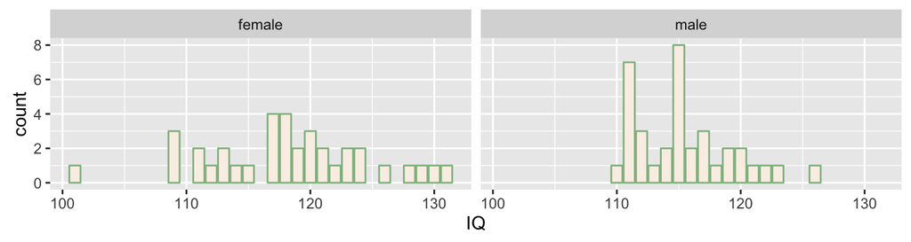

- Independent observations?

## Original Data

Data were collected from schools in a large city on a set of thirty-six children who were identified as gifted children soon after they reached the age of four.

```r
head(gifted)
```

```
##   score fatheriq motheriq speak count read edutv cartoons
## 1   159      115      117    18    26  1.9  3.00     2.00
## 2   164      117      113    20    37  2.5  1.75     3.25
## 3   154      115      118    20    32  2.2  2.75     2.50
## 4   157      123      131    12    24  1.7  2.75     2.25
## 5   156      110      109    17    34  2.2  2.25     2.50
## 6   150      113      109    13    28  1.9  1.25     3.75
```

## Dependence between samples

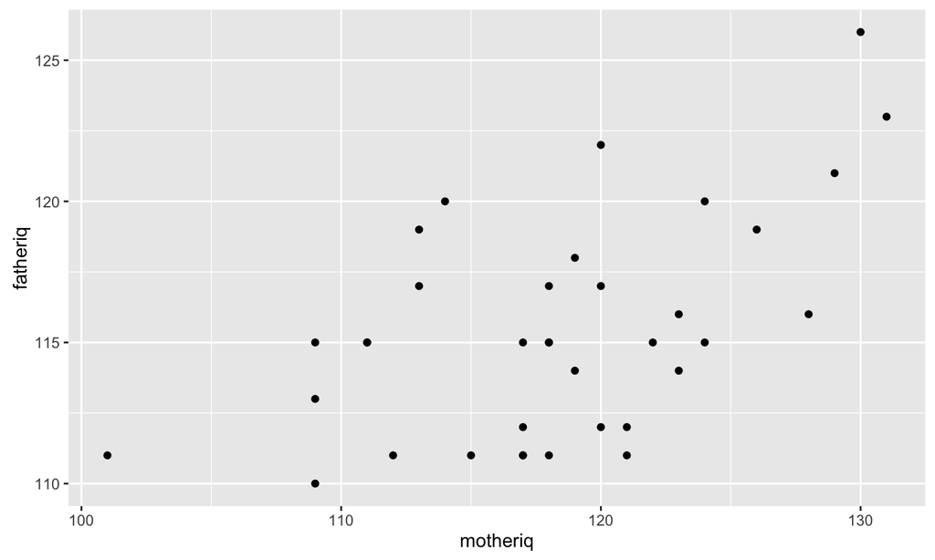

## Paired data

If there is a natural pairing between observations in two groups of size \(n\), it can make more sense to analyze them as a single sample of \(n\) differences.

```r
gifted %>%
  mutate(diff = fatheriq - motheriq) %>%
  select(fatheriq, motheriq, diff)
```

```
##    fatheriq motheriq diff
## 1       115      117   -2
## 2       117      113    4
## 3       115      118   -3
## 4       123      131   -8
## 5       110      109    1
## 6       113      109    4
## 7       118      119   -1
## 8       117      120   -3
## 9       111      112   -1
## 10      122      120    2
## 11      111      117   -6
## 12      112      120   -8
## 13      119      126   -7
## 14      120      114    6
```

[output cut: 22 more lines]

## Paired t-test

\[ H_0: \mu_{diff} = 0 \\ H_A: \mu_{diff} \ne 0 \]

### Check conditions

1. Independent observations
2. Nearly normal population

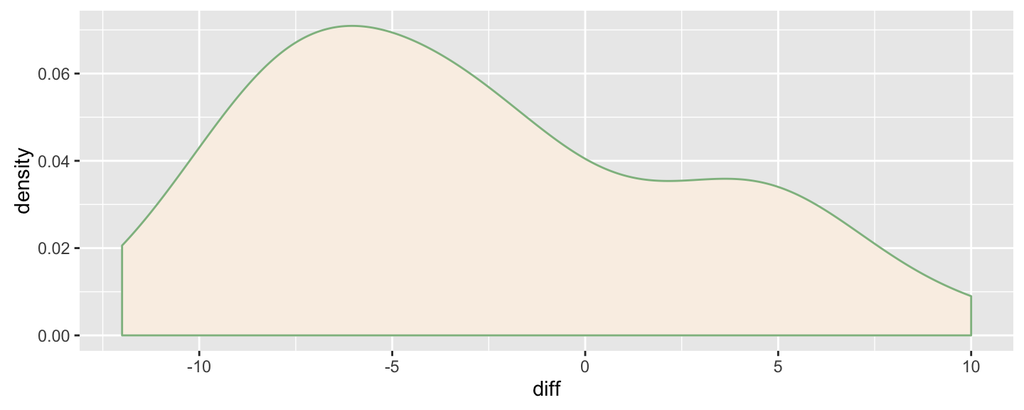

## Paired t-test (cont.)

- Compute a test statistic

```r
(gs <- gifted %>%
  mutate(diff = fatheriq - motheriq) %>%
  summarize(mean = mean(diff), s = sd(diff), n = n()))
```

```
##    mean    s  n
## 1 -2.83 5.52 36
```

```r
(t_obs <- (gs$mean - 0)/(gs$s/sqrt(gs$n)))
```

```
## [1] -3.08
```

```r
pt(t_obs, df = 35) * 2
```

```
## [1] 0.00402
```

## Paired compared

```r
gs$s / sqrt(gs$n)
```

```
## [1] 0.92
```

```r
sqrt(ds$s[1]^2 / ds$n[1] + ds$s[2]^2 / ds$n[2])
```

```
## [1] 1.28
```

While the point estimate is the same in the paired and independent tests, if the data is paired, the dependency leads to a smaller SE.

This principle is widely used in experiment design, e.g. pre- and post-test.

## The takeaway

If your are comparing means between two groups and the data has a natural pairing, analyze the data as **one sample** of differences.

Think of it as an analysis of \(W\), not \(W \sim X\).

## ANOVA

## Wolf River

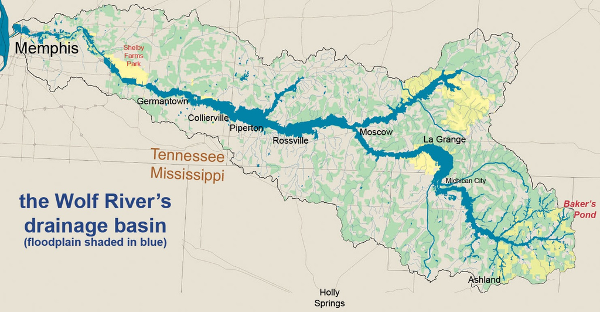

- The Wolf River in Tennessee flows past an abandoned site once used by the pesticide industry for dumping wastes, including hexachlorobenzene (HCB).
- HCB known to cause various cancers and birth defects.

## Wolf River study

- Standard method to test whether HCB is present in a river is to take samples at middepth.
- HCB is denser than water, so is it found at different concentrations at different depths?

```r
str(wolf)
```

```
## 'data.frame':    30 obs. of  3 variables:
##  $ Depth : Factor w/ 3 levels "Bottom","Middepth",..: 3 3 3 3 3 3 3 3 3 3 ...
##  $ Aldrin: num  3.08 3.58 3.81 4.31 4.35 4.4 3.67 5.17 5.17 4.35 ...
##  $ HCB   : num  3.74 4.61 4 4.67 4.87 5.12 4.52 5.29 5.74 5.48 ...
```

```r
head(wolf)
```

```
##     Depth Aldrin  HCB
## 1 Surface   3.08 3.74
## 2 Surface   3.58 4.61
## 3 Surface   3.81 4.00
## 4 Surface   4.31 4.67
## 5 Surface   4.35 4.87
## 6 Surface   4.40 5.12
```

## Wolf River data

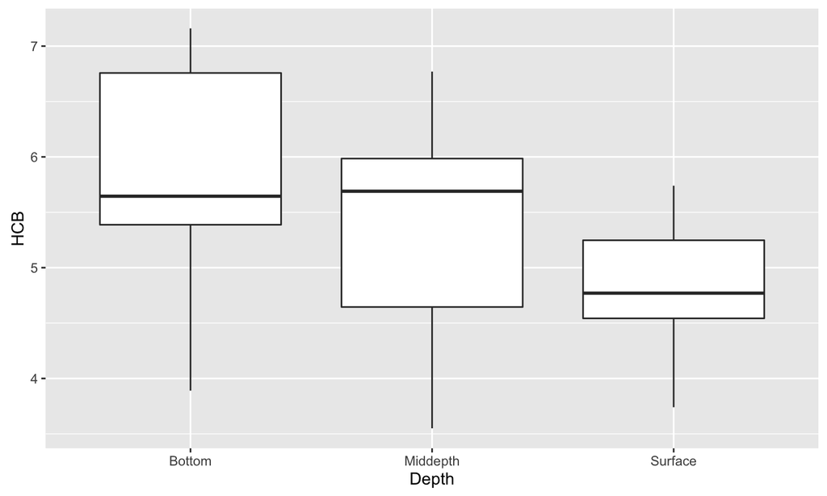

## Wolf River data

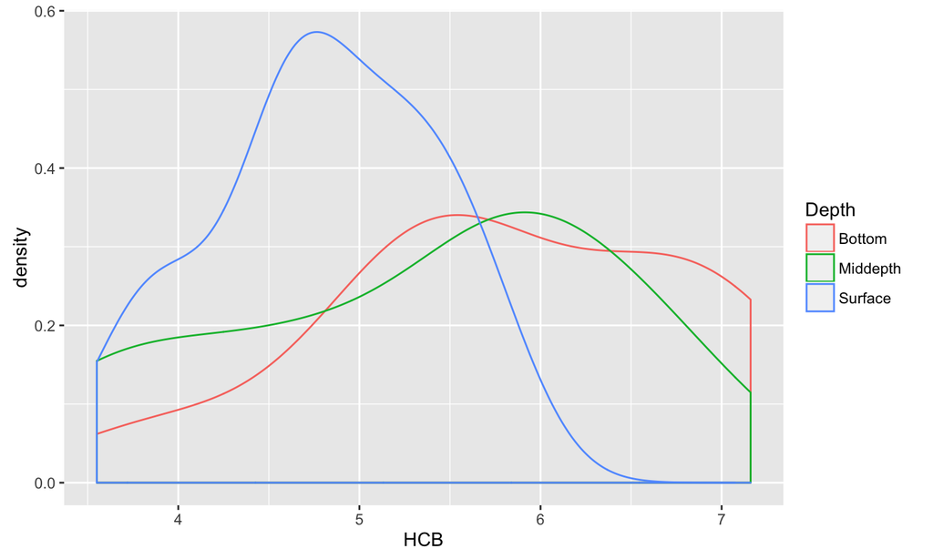

## Wolf River data

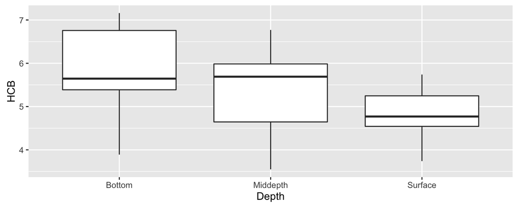

```
##           Df Sum Sq Mean Sq F value
## Depth      2   5.36   2.678    3.03
## Residuals 27  23.85   0.883
```

How big is 3.032?

## ANOVA F-test

\[ H_0: \mu_1 = \mu_2 = \ldots = \mu_k \] \[ H_A: \textrm{At least one } \mu_j \textrm{ is different} \]

We can find the distribution of the F-statistic under the null hypothesis by

- Randomization
- Mathematical approximation

## Sampling dist for F via Randomization

```r
F_stats <- rep(0, 1000)
wolf2 <- wolf

for (i in 1:1000) {
  wolf2$Depth <- sample(wolf2$Depth)
  F_stats[i] <- anova(aov(HCB ~ Depth, data = wolf2))$F[1]
}

qplot(x = F_stats, geom = "density")
```

## Sampling dist for F via Randomization

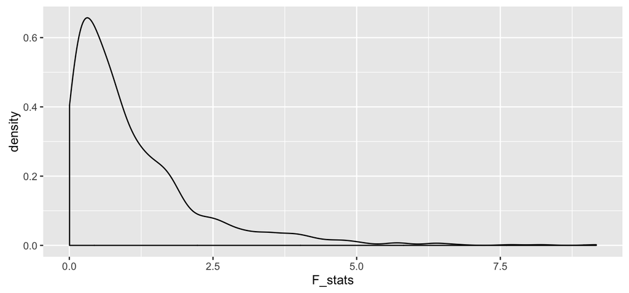

```r
mean(F_stats > 3.032)
```

```
## [1] 0.068
```

## Sampling dist for F via Approximation

If:

1. Independent observations.
2. Approximate normal distributions within groups.
3. Constant variance between groups.

Then the sampling distribution for the \(F\) statistic under the \(H_0\) is well approximated by an F distribution with \(df_1 = k - 1\) and \(df_2 = N - k\). The p-value is represented by the upper tail.

```
## Analysis of Variance Table
##
## Response: HCB
##           Df Sum Sq Mean Sq F value Pr(>F)
## Depth      2   5.36   2.678    3.03  0.065 .
## Residuals 27  23.85   0.883
## ---
## Signif. codes:  0 '***' 0.001 '**' 0.01 '*' 0.05 '.' 0.1 ' ' 1
```

## Sampling dist for F via Approximation

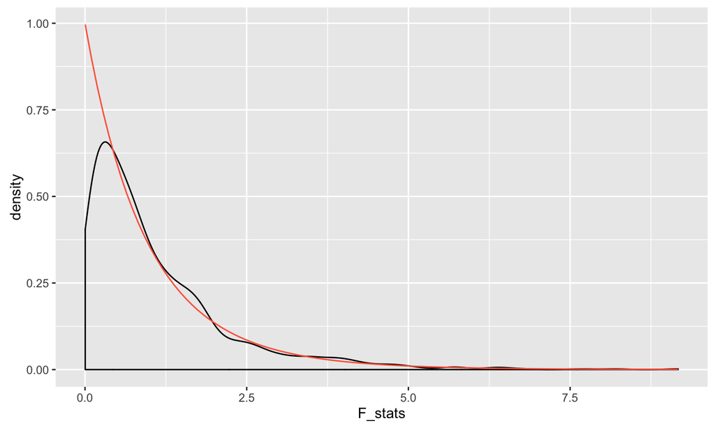

## Wolf River Conclusions

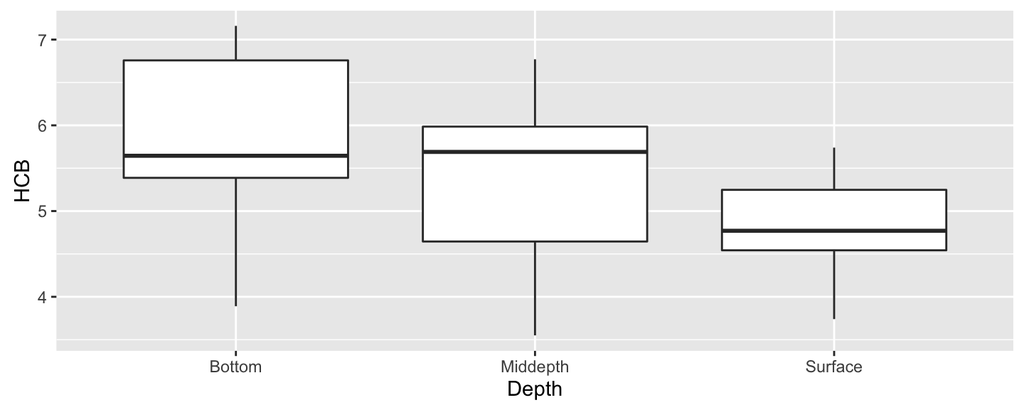